# **Tutorial for RFID Data Handling in R**

### 2.3.5 **EXERCISE**

There are three more files in the folder that come from different feeders that need to be added to the master database.

Make sure to

- add the feeder name column
- save a new Master database with **THE DATE OF THE LAST SET OF FILES YYMMDD**

```r
#if you use the same naming system as before, you will then end up with a dataframe named d220209.

#bind rows for your dataframes from different dates

dfinal<-bind_rows(d220206,d220209)  #the order of the dfs as arguments will determine the order in which they appear in the dataframe. You can change this, but you could here choose the most contemporary date to come second.
```

### 2.3.6 Saving your work and returning to it later

```r
#by default, R will save to your current working directory. So lets change it to a higher directory than we are currently in. Otherwise it may be hard to find which subfolder to save into. You could also create a folder specifically for saving into.

setwd("F:/RWorkspace/GitHub/RFID-workshop/data/feederData")

write.table(dfinal, file = "Masterdf_220209.txt",sep="\t",row.names=FALSE)  #we are saving the dataframe called dfinal as a txt file into our working directory

#you should be able to view this using the following code:
list.dirs(path = "F:/RWorkspace/GitHub/RFID-workshop/data/feederData", full.names = TRUE, recursive = FALSE) #notice that recursive has been changed to F as we only want to see what is in that particular folder, not subfolders.

#Save your R script, and if using github, update the current branch, generate a pull request and merge to your main branch.
#when you close R, it may ask you if you want to save the workspace image. This means you can open that saved file with the data and values from your global environment as you left off. You can select no if that's not relevant. But if you were in the middle of something and needed to stop, that is a useful option.

#If you would like to clear your global environment entirely.
rm(list = ls())
```

### 2.3.7 Use R Markdown to keep track of your data importing and saving

Perhaps in the previous exercise you saved time by cutting and pasting repetitive code and changing the df and feeder number values?. What if you forgot to change the feeder number, or one of the df names? If you are going to do that, make sure you copy and paste, rather than write over code (i.e. replacing df1 with df2 but not keeping the script where you were working with df1). It is important to keep a record of every code you run. But there’s still the possibility that over the course of repetitive copy-pasted code, you lose track of what was done when. R markdown is an excellent tool for keeping track of what you have done and sharing your code with others. Later, as you become more familiar with R you will also be able to write your own functions that will also minimise the chance of code errors/typos.

But for now, lets try R Markdown:

- In R studio go to File>New File> R Markdown…
- Input a title and click ok.
- Delete all the default text except the title
- On the top right hand corner of the R markdown window is a green square with a plus sign and “c”. Click that arrow and chose r script
- You can now write your r script in this gray area
- Use the “#” below r script to leave yourself notes
- write outside of the r script for headings or any other detail you want.
- click the Knit button on the top left hand side of the R markdown window and it will produce a document and save it to your working directory.

Additional resources for independent discovery of concepts and code: - google - stack overflow - chatgpt - [R Markdown Cheat Sheet](https://www.rstudio.com/wp-content/uploads/2015/02/rmarkdown-cheatsheet.pdf)

### 2.3.8 **EXERCISE**

Using the code you produced earlier, create a short R Markdown file and knit it.

### 2.3.9 Answers to EXERCISE

```r
#the files are text files so you need to use a function that calls .txt. files

path2<-"F:/RWorkspace/GitHub/RFID-workshop/data/feederData/F01_220209"
setwd(path2)
# Call the RT file into your environment and call it df1 (dataframe 1)

RTfile<-list.files(path2, pattern = "RT")
df1<-lapply(RTfile, read.delim) #this will appear as a list in your environment
df1<-as.data.frame(df1) #turn it into a dataframe
head(df1)
df1<-cbind(df1, feeder='F01')

path3<-"F:/RWorkspace/GitHub/RFID-workshop/data/feederData/F02_220209"
setwd(path3)
# Call the RT file into your environment and call it df2 (dataframe 2)

RTfile<-list.files(path3, pattern = "RT")
df2<-lapply(RTfile, read.delim) #this will appear as a list in your environment
df2<-as.data.frame(df2) #turn it into a dataframe
head(df2)
df2<-cbind(df2, feeder='F02')

path4<-"F:/RWorkspace/GitHub/RFID-workshop/data/feederData/F03_220209"
setwd(path4)
# Call the RT file into your environment and call it df2 (dataframe 3)

RTfile<-list.files(path4, pattern = "RT")
df3<-lapply(RTfile, read.delim) #this will appear as a list in your environment
df3<-as.data.frame(df3) #turn it into a dataframe
head(df3)
df3<-cbind(df3, feeder='F03')

d220209<-bind_rows(df1,df2,df3)
```

# 3 Tutorial 3: Introduction to RFID Data Filtering

## 3.1 Get set up

Open R Studio

### 3.1.1 Check R packages installed

```r
#load the following packages
library(tidyverse)
library(rmarkdown)
library(dplyr)
library(tidyr)
library(lubridate)
library(ggplot2)
library(stringi) #may not need this
library(magrittr) #may not need this
```

### 3.1.2 Download resources necessary for the workshop

Download the resources from **[my github page](https://github.com/DrGLDavidson/RFID-workshop)**

## 3.2 Import your dataset to your environment from your working directory.

```r
require("knitr")
opts_knit$set(root.dir = "F:/RWorkspace/GitHub/RFID-workshop/data/outputFiles")

#clear the global environment so we don't have any conflicts with the next steps

rm(list = ls(all.names = TRUE))

#choose the appropriate working directory

setwd("F:/RWorkspace/GitHub/RFID-workshop/data/outputFiles")

#call your most recent dataset of merged feeder data.

df<-read.delim("Masterdf_220209.txt", header=TRUE)
head(df)
```

```
##    F                Date Hmsec     ID Event Channel    Dur  Clks   Freq Edges
## 1 D  2022-02-04 09:16:45   196 c1935     82       0 114855 61559 126720     1
## 2 D  2022-02-04 09:17:11   896 c1935     83       0 106855     0 125184     0
## 3 D  2022-02-04 09:17:11   648 c1935     83       0 114855    27 126208   156
## 4 D  2022-02-04 09:17:12   650 c1935     83       0 106855    37 126208   843
## 5 D  2022-02-04 09:18:30   270 c1935     84       0      2 62210 126208     1
## 6 D  2022-02-04 09:20:09   667 c1935     85       0 119946 17899 126464     1
##   Reps Type  TagID_hex Mfr TagID feeder
## 1    1    0             NA    NA    F01
## 2    0    0             NA    NA    F01
## 3    1    1 0300024FEF  NA    NA    F01
## 4    1    0             NA    NA    F01
## 5    1    0             NA    NA    F01
## 6    1    0             NA    NA    F01
```

```r
names(df)
```

```
##  [1] "F"         "Date"      "Hmsec"     "ID"        "Event"     "Channel"
##  [7] "Dur"       "Clks"      "Freq"      "Edges"     "Reps"      "Type"
## [13] "TagID_hex" "Mfr"       "TagID"     "feeder"
```

## 3.3 Data filtering

### 3.3.1 Remove misreads (i.e. erroneous TagID_hex values)

Ocassionally the RFID reader will incorrectly read an tag. This may be because the bird does not properly land on the perch to feed, and so these ‘misreads’ can be removed. To remove misreads, we need to match the feeder data against known tagged bird IDs (i.e. Passive Integrative Transponder (PIT) tag numbers, aka TagID_hex). I have provided a file with a list of PIT tags and corresponding metadata (species, age, sex etc.). Note this data is NOT from the UEA population.

```r
#upload a list of your known PIT tag IDs. Notice that the file is a .csv, rather than .txt
PIT<-read.csv(file="F:/RWorkspace/GitHub/RFID-workshop/data/PITList_tutorial.csv", header=TRUE)
names(PIT)
```

```
##  [1] "date"        "time"        "btoRingType" "btoID"       "species"
##  [6] "pitTYPE"     "pitID"       "age"         "sex"         "wing"
## [11] "weight"
```

```r
#note that the ring type (BTO and PIT) refer to whether it was a new bird (first time given the ring), or retrap (already had the ring). It is possible that a bird may already have a BTO ring (R) but not a PIT tag (N). However, in these cases, the code was meant to be A for added (but you can ignore this detail for now).

#check how many unique PIT tag IDs there are, it should match the number of observations (global environment). If it does not match, it suggests duplicates. Duplicates would matter if you are planning to merge the metadata and you want it to be a particular date (e.g. age of a bird when it was first fitted with a ring)

length(unique(PIT$pitID))
```

```
## [1] 4033
```

```r
#to merge/match PIT tags from two files you must ensure the header that contains the values of interest are named the same across files. Currently they are not.

head(PIT)
```

```
##         date  time btoRingType   btoID species pitTYPE      pitID age sex wing
## 1 02/01/2023 11:17           R AJT8236      BT       A 3B0018373B   5       65
## 2 13/10/2022 12:46           C AYN4586      BT       A 3B00184BED   3       61
## 3 29/09/2022 09:33           R TV35268      GT       A 3B00187309   3   M   77
## 4 09/11/2021 09:59           R AAJ5735      BT       A 3B0018FA87   3       62
## 5 09/11/2021 11:54           R AAJ5802      BT       A 3B00193EAD   3       63
## 6 07/11/2021 11:26           R AJT8125      BT       A 3B001904FD   3       66
##   weight
## 1   11.5
## 2    9.8
## 3   19.3
## 4   10.9
## 5   10.9
## 6   10.8
```

```r
head(df)
```

```
##    F                Date Hmsec     ID Event Channel    Dur  Clks   Freq Edges
## 1 D  2022-02-04 09:16:45   196 c1935     82       0 114855 61559 126720     1
## 2 D  2022-02-04 09:17:11   896 c1935     83       0 106855     0 125184     0
## 3 D  2022-02-04 09:17:11   648 c1935     83       0 114855    27 126208   156
## 4 D  2022-02-04 09:17:12   650 c1935     83       0 106855    37 126208   843
## 5 D  2022-02-04 09:18:30   270 c1935     84       0      2 62210 126208     1
## 6 D  2022-02-04 09:20:09   667 c1935     85       0 119946 17899 126464     1
##   Reps Type  TagID_hex Mfr TagID feeder
## 1    1    0             NA    NA    F01
## 2    0    0             NA    NA    F01
## 3    1    1 0300024FEF  NA    NA    F01
## 4    1    0             NA    NA    F01
## 5    1    0             NA    NA    F01
## 6    1    0             NA    NA    F01
```

```r
#rename the header in PIT to match that of df
names(PIT)[names(PIT) == "pitID"] <- "TagID_hex"
names(PIT)
```

```
##  [1] "date"        "time"        "btoRingType" "btoID"       "species"
##  [6] "pitTYPE"     "TagID_hex"   "age"         "sex"         "wing"
## [11] "weight"
```

If we view df, we will also see there are a lot of rows with no TagID_hex. This is because non-tagged birds often land on the feeder and it shows up as a time stamp with no corresponding TagID_hex. Lets remove blank rows, otherwise there will be many rows that can’t merge with PIT.

```r
df <- with(df, df[!(TagID_hex == "" | is.na(TagID_hex)), ])
```

Now you can merge dataframes by their shared TagID_hex value. In addition, if there are any missing TagID_hex values from PIT, it will be indicated with “NA”. In other words, if a bird that is not on our database was detected at the feeder, it will show up as NA. This code also returns any values from our PIT dataframe that was not on df. In otherwords, an NA is given if the bird on our database was never detected at the feeders.

```r
df1 <- merge(df, PIT, by = "TagID_hex", all = TRUE)
df1[is.na(df1)] <- "NA"
```

We are only interested in the TagID_hex that was detected at the feeder, but not on our database. We will filter these into a new dataframe called missing. We extract these as values that did not have a BTO

```r
missing<-df1%>%
  filter(btoID=="NA")
```

why do we do this with the header btoRing? Because TagID_hex is now merged across dataframes, so this is no longer informative for missing data. Any of the headers from the PIT dataframe would work, but we are using btoID.

```r
#there are 54 observations where there is no corresponding PIT tag.
#create a list of TagID_hex reads that did not have a match:

uniqueMisreads <- unique(missing$TagID_hex)
uniqueMisreads
```

```
## [1] "01103F3B1B" "0300024FEF"
```

there are two tags. “0300024FEF” is our reference tag. It is the tag that the experimenter uses to test the feeders and mark when experiments start and end. “01103F3B1B” looks like a genuine tag. But is it a misread or missing data from our PIT tag data? To answer this, double check the master ringing database to see if that tag is there. If it is not there, assume it is a misread. If it is there, add it to the PIT database and re-run your code.

```r
#save your misreads for your records

path_out = 'F:/RWorkspace/GitHub/RFID-workshop/data/outputFiles'

write.csv(uniqueMisreads, file.path(path_out, 'uniqueMisreadsFeeders.csv'))

#assuming we have resolved this, merge df and PIT again, using a different code that wont keep all NAs from the PIT file, but will remove NAs from the btoRing column, using the argument all = FALSE

df1 <- merge(df, PIT, by = "TagID_hex", all = FALSE)

#this returns a dataframe that is 1214 observations.
1268-1214  #maths to check number of observations makes sense
```

```
## [1] 54
```

The above subtraction equals 54, which is the same number of observations from our dataframe “missing”. This makes sense.

Another way you can merge dataframes is using the package dplyr and the following code:

```r
df2<-left_join(df, PIT ,by ="TagID_hex")

# and then we have to remove NAs with another chunk of code

df2<-df2[!is.na(df2$btoRing),]

write.table(df2, file = "Masterdf_noMisreads.txt",sep="\t",row.names=FALSE)

#clear the global environment so we don't have any conflicts with the next steps

rm(list = ls(all.names = TRUE))
```

### 3.3.2 Filter repetitive RFID reads within a single visit

A common goal in quantifying bird behaviour is to extract the number of visits a bird makes to a feeder. Due to the nature of the RFID device, multiple rows will be recorded if the bird sits on the perch while feeding, yet this should be considered a single visit.

**SKIP THIS IF YOU ARE QUANTIFYING TOTAL PERCH TIME.** Filtering repeated reads removes the information needed to estimate how long a bird stayed on the perch. If that is your aim, see the section on total time on the perch in Tutorial 4.

```r
#As we will be working with time, we need to check how our dataframe is named and organised
df2<-read.delim("Masterdf_noMisreads.txt", header=TRUE)

head(df2)
```

```
##    F                Date Hmsec     ID Event Channel    Dur Clks   Freq Edges
## 1 D  2022-02-04 10:01:13   467 c1935    146       0      0   32 126464   264
## 2 D  2022-02-04 11:06:32   770 c1935    147       0      6   39 126208   426
## 3 D  2022-02-04 11:17:36   871 c1935    148       0 105573   51 126464  1168
## 4 D  2022-02-04 11:17:40   123 c1935    148       0 121015   27 126208   174
## 5 D  2022-02-04 11:17:41   946 c1935    148       0 121015   27 126208   566
## 6 D  2022-02-04 11:17:43   794 c1935    148       0 119945   35 125952   272
##   Reps Type  TagID_hex Mfr TagID feeder       date  time btoRingType   btoID
## 1    2    1 01103FC949  NA    NA    F01 09/01/2021 11:03           R AKL0680
## 2    3    1 01103F7DB1  NA    NA    F01 03/10/2021 10:30           R AAJ5894
## 3    5    1 01103F3BED  NA    NA    F01 17/10/2021 10:09           R AAJ5895
## 4    1    1 01103F3BED  NA    NA    F01 17/10/2021 10:09           R AAJ5895
## 5    1    1 01103F3BED  NA    NA    F01 17/10/2021 10:09           R AAJ5895
## 6    2    1 01103F3BED  NA    NA    F01 17/10/2021 10:09           R AAJ5895
##   species pitTYPE age sex wing weight
## 1      BT       R   5   M   64   11.7
## 2      GT       R   3   F   73   16.3
## 3      GT       R   3   M   75   18.5
## 4      GT       R   3   M   75   18.5
## 5      GT       R   3   M   75   18.5
## 6      GT       R   3   M   75   18.5
```

There are two separate date columns and a time column. This is because we merged the feeder data with ringing data.

```r
#rename ringing columns

names(df2)[names(df2) == "date"] <- "dateRinged"
names(df2)[names(df2) == "time"] <- "timeRinged"

#rename feeder date column to indicate it also includes hours, minutes and seconds

names(df2)[names(df2) == "Date"] <- "dateTime"

names(df2)
```

```
##  [1] "F"           "dateTime"    "Hmsec"       "ID"          "Event"
##  [6] "Channel"     "Dur"         "Clks"        "Freq"        "Edges"
## [11] "Reps"        "Type"        "TagID_hex"   "Mfr"         "TagID"
## [16] "feeder"      "dateRinged"  "timeRinged"  "btoRingType" "btoID"
## [21] "species"     "pitTYPE"     "age"         "sex"         "wing"
## [26] "weight"
```

create a new column with the date only

```r
df2$date<-date(df2$dateTime)

#cleanup the dataframe by selected the columns and order we want them to appear

df2<-df2%>%
  select(date, dateTime, Hmsec, ID, Event, Channel, Dur, Clks, Freq, Edges, Reps, Type, TagID_hex, feeder, dateRinged, timeRinged, btoRingType, btoID, species, pitTYPE, age, sex, wing, weight)
names(df2)
```

```
##  [1] "date"        "dateTime"    "Hmsec"       "ID"          "Event"
##  [6] "Channel"     "Dur"         "Clks"        "Freq"        "Edges"
## [11] "Reps"        "Type"        "TagID_hex"   "feeder"      "dateRinged"
## [16] "timeRinged"  "btoRingType" "btoID"       "species"     "pitTYPE"
## [21] "age"         "sex"         "wing"        "weight"
```

```r
#we need to change the class of the timeDate column as a POSIX class.

df3<-df2%>%
  mutate(dateTime=ymd_hms(dateTime))

class(df3$dateTime)
```

```
## [1] "POSIXct" "POSIXt"
```

create a column that calculates the time difference with previous row of a dataframe grouped by date, feeder and RFID

consider why you are grouping by these columns. The time interval will only be calculated PER date PER feeder and PER tag. If you wanted to know the time interval between days as well, then you would not group by date. Or if you wanted an interval regardless or feeder, you would remove feeder from your grouping argument.

```r
df4<-df3 %>%
  arrange(dateTime)%>%
  group_by(date, feeder, TagID_hex) %>%
  mutate(timeSincePreviousVisit = dateTime - lag(dateTime))%>%
  arrange(TagID_hex, feeder, dateTime)%>%
  ungroup()%>%
  select(feeder, TagID_hex,date, dateTime, timeSincePreviousVisit)

#look at the output of just those selected columns to see we have produced what we think we want
View(df4)
#0 sec was calculated if the bird was on the feeder within the same seconds
#NA is given if it is the birds' first visit to feeder X for that date

#rerun the above code without the select() argument so we have the full dataframe of variables

df4<-df3 %>%
  arrange(dateTime)%>%
  group_by(date, feeder, TagID_hex) %>%
  mutate(timeSincePreviousVisit = dateTime - lag(dateTime))%>%
  arrange(TagID_hex, feeder, dateTime)%>%
  ungroup()


#the new column timeSincePreviousVisit has "secs" and we don't want that, so lets remove it

df4$timeSincePreviousVisit <- gsub(' secs', '', df4$timeSincePreviousVisit)

#the column timeSincePreviousVisit needs to be numeric for graphical purposes and for filtering based on greater than/less than values

df4$timeSincePreviousVisit <- as.numeric(as.character(df4$timeSincePreviousVisit))
class(df4$timeSincePreviousVisit)
```

```
## [1] "numeric"
```

Create a dataframe of successive visits that are less than 20 seconds so we can graph how frequently birds are read at the feeder use the “select” argument to extract only the column named timesSincePreviousVisit

```r
df5<-df4%>%
  filter(timeSincePreviousVisit <=20)%>%
  select(timeSincePreviousVisit)
class(df5$timeSincePreviousVisit)
```

```
## [1] "numeric"
```

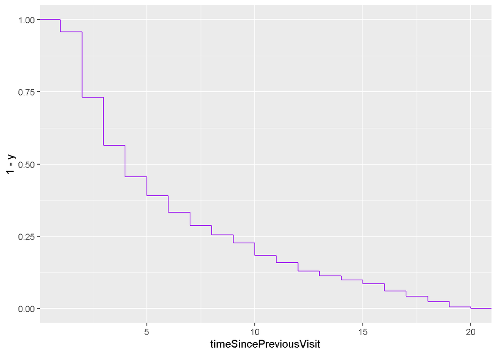

```r
#cumulative frequency graph
ggplot(df5, aes(timeSincePreviousVisit, y= 1-..y..))+
  stat_ecdf(geom = "step", color="purple")
```

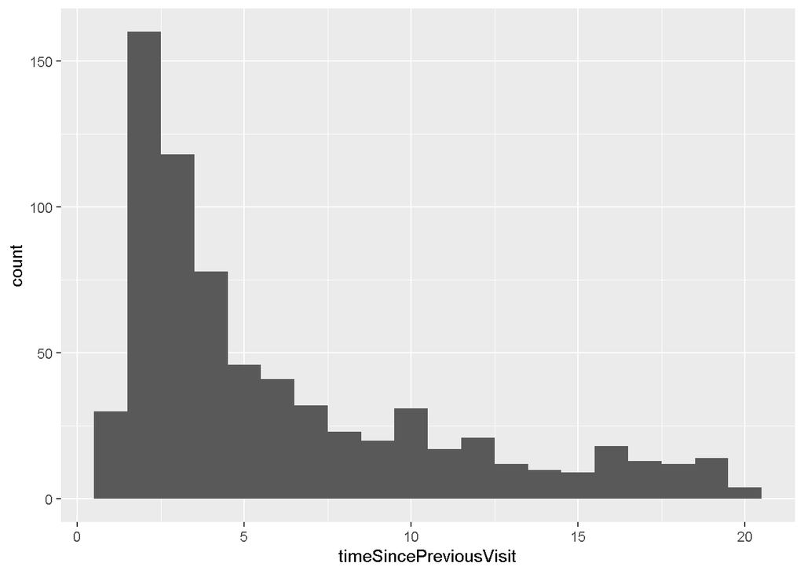

```r
#histogram
ggplot(df5, aes(x=timeSincePreviousVisit)) +geom_histogram(binwidth = 1)
```

```r
#it appears that visit frequency drops after 2 seconds, but it is not a clear drop.

#Most of the literature does a cut off at 2 or 3 seconds.

#Filter dataset to remove visits that were within 2 seconds of eachother

#note that there are NAs because it was the first visit of that bird to that feeder on that date.
#Keep the NAs (do NOT replace them with text) so the column stays numeric and seconds can still be calculated/compared later.
#filter() drops NAs by default, so we must explicitly keep them with is.na()

df6<-df4%>%
  filter(is.na(timeSincePreviousVisit) | timeSincePreviousVisit>2)

df7<-df6%>%
  arrange(dateTime, TagID_hex,feeder)
view(df7)


write.table(df7, file = "Masterdf_noRepeats.txt",sep="\t",row.names=FALSE)

rm(list = ls(all.names = TRUE))
```

## 3.4 Check for RFID malfunction. In otherwords, periods of missing data.

we have a dataframe with time since previous visit grouped by individual and by date. We would expect big time gaps across all individuals if a feeder was down.

```r
#call the dataframe from your working directory
df1<-read.delim("Masterdf_noRepeats.txt", header=TRUE)

#make dateTime a PosiX class object
df1<-df1%>%
  mutate(dateTime=ymd_hms(dateTime))

class(df1$dateTime)
```

```
## [1] "POSIXct" "POSIXt"
```

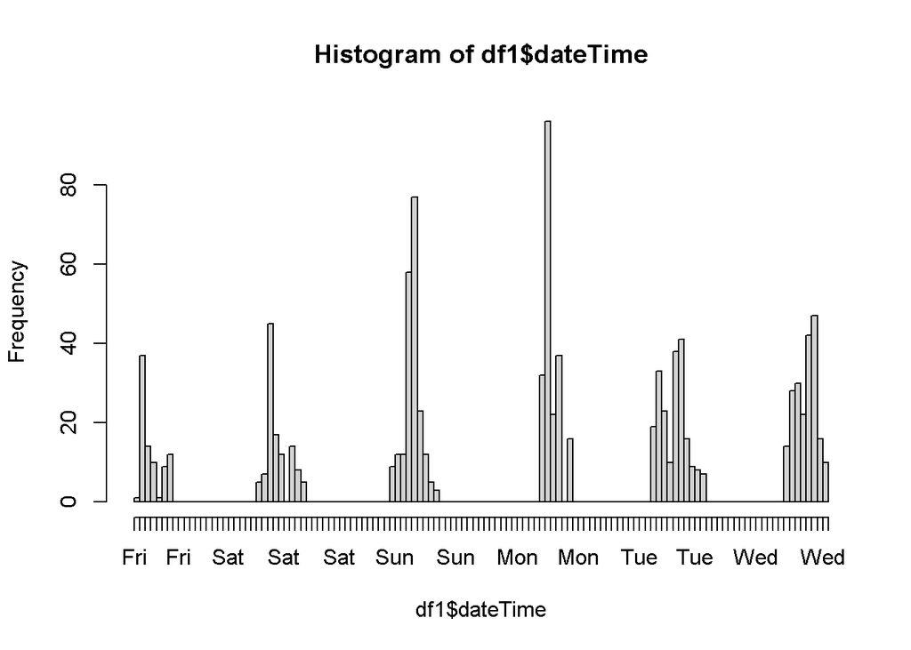

```r
#plot a histogram of visit frequency over hours. I think days of week is just assigned to start on friday.
hist(df1$dateTime, breaks = "hours", plot = TRUE, freq = TRUE, format)
```

We see there are periods of inactivity but that is regular and likely corresponds to nightime hours.

However, this plot does not indicate whether a given feeder was inactive, as it lumps all three feeders together.

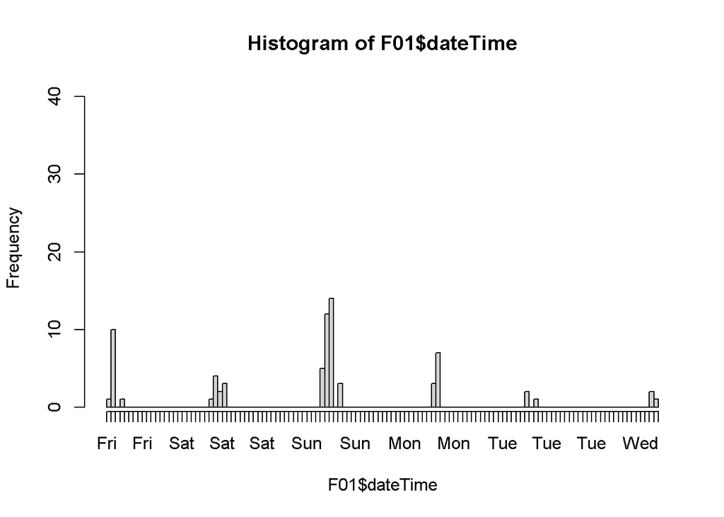

```r
#create new dataframes filtered by feeder.

F01<-df1%>%
  filter(feeder=='F01')

#plot a histogram of visit frequency over hours for feeder F01
hist(F01$dateTime, breaks = "hours", plot = TRUE, freq = TRUE, format, ylim=c(1, 40) ) #ylim is set because I already visualised all the plots and chose to standardise the y axis so they are comparable. You will have to edit this for your own data.
```

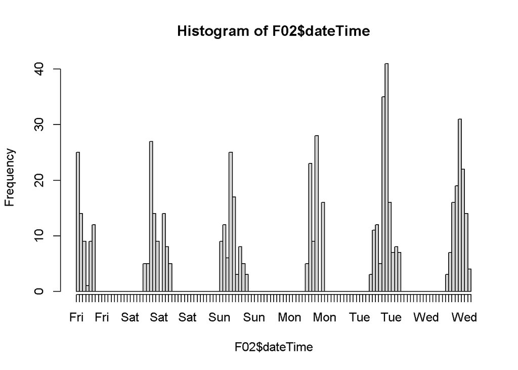

```r
F02<-df1%>%
  filter(feeder=='F02')

#plot a histogram of visit frequency over hours for feeder F02
hist(F02$dateTime, breaks = "hours", plot = TRUE, freq = TRUE, format, ylim=c(1, 40))
```

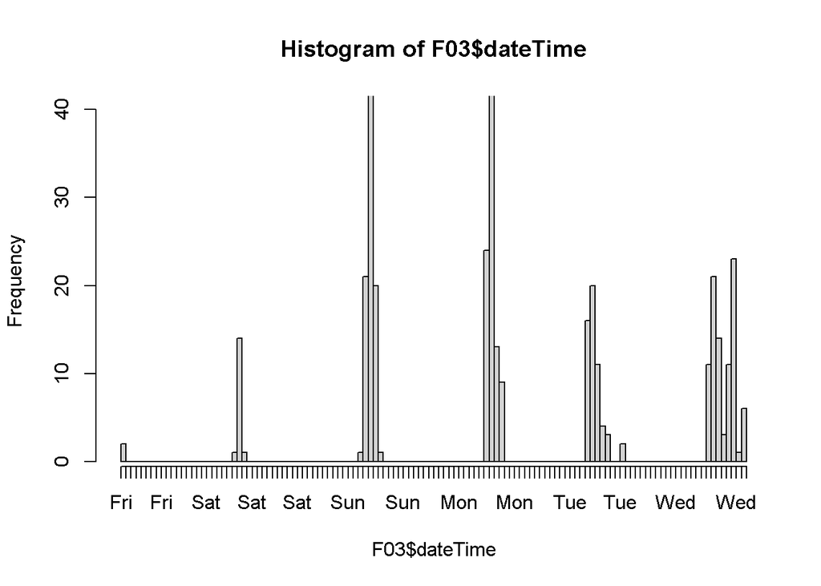

```r
F03<-df1%>%
  filter(feeder=='F03')

#plot a histogram of visit frequency over hours for feeder F03
hist(F03$dateTime, breaks = "hours", plot = TRUE, freq = TRUE, format, ylim=c(1, 40))
```

These three feeders have very different distributions of visits, and so this is very suspicious. But there doesn’t seem to be a specific day where feeders are entirely down, except perhaps the first day of the series on F03.

You will need to consider your experimental design and what is expected. In fact this data is from feeders that contained different food types and one feeder was only available for a short time period compared to the others.

## 3.5 Removing periods of missing data.

If one of the feeders malfunctioned for a day and the entire experiment depends on all feeders working in tandem, this may be good reason to remove data for this day, but see below.

```r
#first check the dates data was collected
unique(df1$date)
```

```
## [1] "2022-02-04" "2022-02-05" "2022-02-06" "2022-02-07" "2022-02-08"
## [6] "2022-02-09"
```

```r
#assuming feeder03 had a malfunction on the first day (2022-02-04), remove rows that meet the conditions of having the following dates in the column "date"
df2<-df1[!(df1$date=="2022-02-04") ,]
#the date should no longer be in the dataframe
unique(df2$date)
```

```
## [1] "2022-02-05" "2022-02-06" "2022-02-07" "2022-02-08" "2022-02-09"
```

```r
#if you needed to remove multiple date, the syntax is as follows:

df3<-df1[!(df1$date=="2022-02-04" |df1$date=="2022-02-05" |df1$date=="2022-02-06" ),]
unique(df3$date)
```

```
## [1] "2022-02-07" "2022-02-08" "2022-02-09"
```

How to deal with missing data depends on the experiment and analysis.

Examples:

- For social network analysis, the Machine Learning algorithms workout flocking events from the streams of data over periods of weeks and therefore these analyses are less sensitive to malfunctions, provided you have sufficient periods when the feeders are working
- If you were calculating frequency of nestbox visits per day, and the device failed part of the day, then you would consider not including it that day, or correcting for malfunction time (e.g. frequncy per hour, not by day, or corrected for hours working)
- If you had a learning experiment where birds had access to one out of an array of feeders, for example, [Reichert et al 2020](https://doi.org/10.1098/rsos.192107), they retained data and added a co-variable for feeder malfunction (assigned, not assigned) in their statistical analyses. *We therefore included the duration of feeder malfunction before the bird reached learning criterion for both the assigned (own) feeder and separately for any of the other feeders in that site as additional fixed effects.*

An alternative approach would be to add a column for each feeder and indicate whether it had malfunctioned for each row.

```r
#create a new dataframe where it indicates that feeder 03 malfunctioned.
df4<-df1%>%
  mutate(feeder03Malf = case_when(date =='2022-02-04' ~'Y',
                                  date =='2022-02-05'~'Y' ,
                                  date =='2022-02-06'~'Y'))
```

# 4 Tutorial 4: Quantifying Feeder Visits

## 4.1 Get set up

Open R Studio

### 4.1.1 Check R packages installed

```r
#load the following packages
library(tidyverse)
library(rmarkdown)
library(dplyr)
library(tidyr)
library(lubridate)
library(ggplot2)
library(stringi) #may not need this
library(magrittr) #may not need this
```

### 4.1.2 Download resources necessary for the workshop

Download the resources from **[my github page](https://github.com/DrGLDavidson/RFID-workshop)**

## 4.2 Import your dataset to your environment from your working directory.

```r
#clear the global environment so we don't have any conflicts with the next steps

rm(list = ls(all.names = TRUE))

#choose the appropriate working directory

setwd("F:/RWorkspace/GitHub/RFID-workshop/data/outputFiles")

#call your most recent dataset

df<-read.delim("Masterdf_noRepeats.txt", header=TRUE)
head(df)
```

```
##         date            dateTime Hmsec     ID Event Channel    Dur Clks   Freq
## 1 2022-02-04 2022-02-04 10:01:13   467 c1935    146       0      0   32 126464
## 2 2022-02-04 2022-02-04 11:06:19   516 c1931  15597       0 127943   26      0
## 3 2022-02-04 2022-02-04 11:06:32   770 c1935    147       0      6   39 126208
## 4 2022-02-04 2022-02-04 11:17:36   871 c1935    148       0 105573   51 126464
## 5 2022-02-04 2022-02-04 11:17:40   123 c1935    148       0 121015   27 126208
## 6 2022-02-04 2022-02-04 11:17:48   543 c1931  15598       0      0   39      0
##   Edges Reps Type  TagID_hex feeder dateRinged timeRinged btoRingType   btoID
## 1   264    2    1 01103FC949    F01 09/01/2021      11:03           R AKL0680
## 2   442    1    1 01103F7DB1    F02 03/10/2021      10:30           R AAJ5894
## 3   426    3    1 01103F7DB1    F01 03/10/2021      10:30           R AAJ5894
## 4  1168    5    1 01103F3BED    F01 17/10/2021      10:09           R AAJ5895
## 5   174    1    1 01103F3BED    F01 17/10/2021      10:09           R AAJ5895
## 6   388    3    1 01103FE3B3    F02 07/11/2021      12:15           R AJT8118
##   species pitTYPE age sex wing weight timeSincePreviousVisit
## 1      BT       R   5   M   64   11.7                     NA
## 2      GT       R   3   F   73   16.3                     NA
## 3      GT       R   3   F   73   16.3                     NA
## 4      GT       R   3   M   75   18.5                     NA
## 5      GT       R   3   M   75   18.5                      4
## 6      GT       R   3   F   72   18.1                     NA
```

```r
names(df)
```

```
##  [1] "date"                   "dateTime"               "Hmsec"
##  [4] "ID"                     "Event"                  "Channel"
##  [7] "Dur"                    "Clks"                   "Freq"
## [10] "Edges"                  "Reps"                   "Type"
## [13] "TagID_hex"              "feeder"                 "dateRinged"
## [16] "timeRinged"             "btoRingType"            "btoID"
## [19] "species"                "pitTYPE"                "age"
## [22] "sex"                    "wing"                   "weight"
## [25] "timeSincePreviousVisit"
```

## 4.3 Total number of visits per feeder, per day

```r
# a new dataframe that counts the total number of visits per feeder per individual, per date.
individualVisits<-df%>%
  count(feeder, TagID_hex, date, sort = TRUE)

# rename n column "visits"
names(individualVisits)[names(individualVisits) == "n"] <- "visits"  #rename columns
 names(individualVisits)
```

```
## [1] "feeder"    "TagID_hex" "date"      "visits"
```

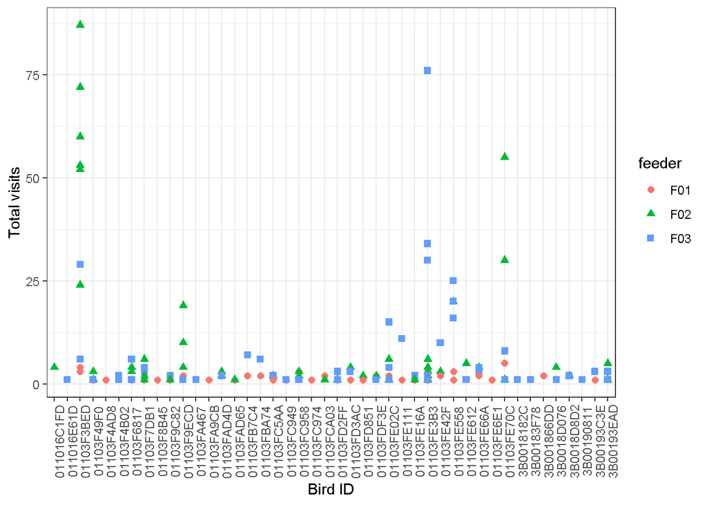

```r
# visualise the data on a figure using ggplot

individualVisits%>%
 ggplot(aes(x = TagID_hex, y = visits, color = feeder))+  #specify axis labels and groupings
  labs(x = "Bird ID", y = "Total visits") + #specify axis labels
  geom_point(aes(shape=feeder), size=2) + # specify shape and size of points for the variable feeder
  theme_bw() +   theme(axis.text.x = element_text(angle=90)) #removes the default gray background and rotates x labels.
```

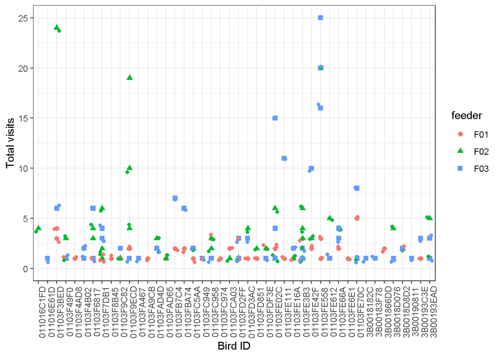

```r
#Note that each data point is a unique date. Therefore this plot gives you information not only on the number of visits they make on a given day, but also over how many days.
#Because of the outliers, it's difficult to resolve what is happening between 0 and 20 visits.

# Restrict axis limits and minimise datapoint overlap

individualVisits%>%
 ggplot(aes(x = TagID_hex, y = visits, color = feeder))+  #specify axis labels and groupings
  labs(x = "Bird ID", y = "Total visits") + #specify axis labels
  geom_point(aes(shape=feeder), size=2) + # specify shape and size of points for the variable feeder
  theme_bw() +   theme(axis.text.x = element_text(angle=90))+
  geom_point() + #removes the default gray background and rotates x labels.
 ylim(0, 25) + #specify axis limits
    geom_point(position = position_jitter(width = 0.3)) #jitter the points along a horizontal axis to minimise overlap
```

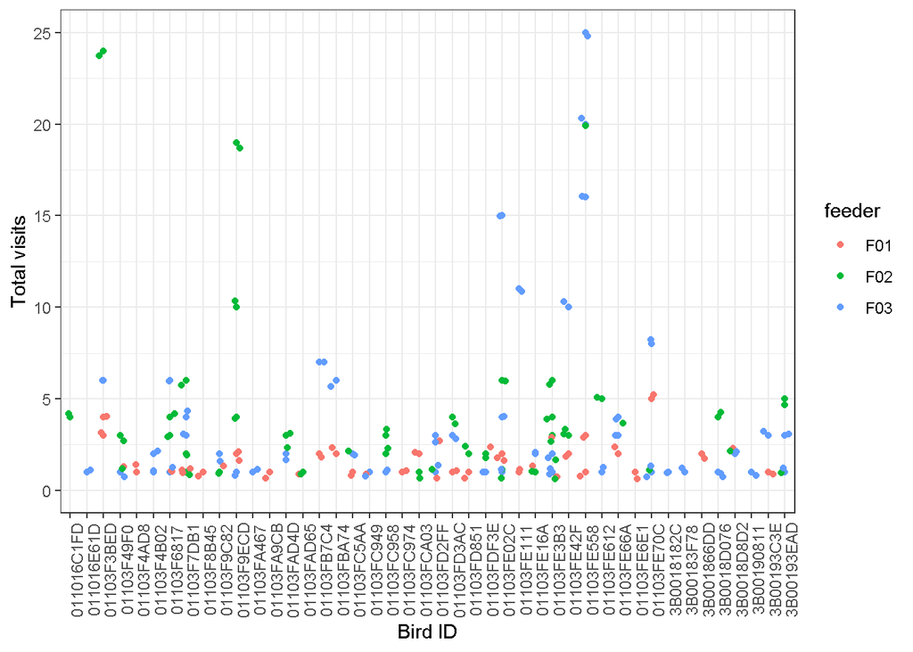

```r
# can also remove shape for visualization

individualVisits%>%
 ggplot(aes(x = TagID_hex, y = visits, color = feeder))+  #specify axis labels and groupings
  labs(x = "Bird ID", y = "Total visits") + #specify axis labels
  geom_point(size=1) + # specify size ONLY of points for the variable feeder
  theme_bw() +   theme(axis.text.x = element_text(angle=90))+
  geom_point() + #removes the default gray background and rotates x labels.
 ylim(0, 25) + #specify axis limits
    geom_point(position = position_jitter(width = 0.3))
```

```r
# a new dataframe that counts the proportion an individual visits a feeder relative to the other feeders, per day.
ProportionVisits<-individualVisits%>%
  group_by(TagID_hex, date)%>%
  arrange(TagID_hex)%>%
  mutate(freq = visits / sum(visits))%>%
  ungroup()
```

## 4.4 Proportion of visits per feeder, per day

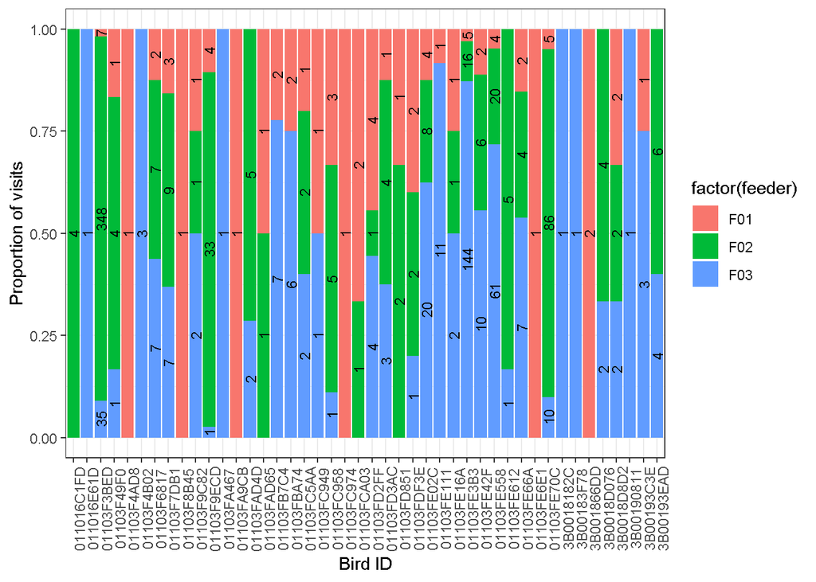

```r
#a new dataframe that counts the proportion an individual visits a feeder relative to the other feeders, per day.
ProportionVisits<-individualVisits%>%
  group_by(TagID_hex, date)%>%
  arrange(TagID_hex)%>%
  mutate(proportion = visits / sum(visits))%>%
  ungroup()


# plot proportions. Better to use the original dataframe as the following code counts each line as a visit

ggplot(df,aes(x=factor(TagID_hex),fill=factor(feeder)))+
  geom_bar(position="fill")+
  geom_text(aes(label=..count..),stat='count',position=position_fill(vjust=0.5), angle=90, size=3) +
  #scale_x_discrete (labels = c("F01","F02","F03")) +
  theme_bw() +   theme(panel.grid.major = element_blank(),
                       panel.grid.minor = element_blank(), axis.line = element_line(colour = "black"),
                       panel.border = element_rect(linetype = "solid", colour = "black", size=.8)) +
  # scale_fill_manual("Feeder", values = c("1" = "gray49", "0" = "gray84"))+
  theme(text=element_text(size=12,  family="serif"),
        axis.ticks = element_line(colour = "black", size = .6)) +
  labs(x = "Bird ID") +
  labs(y = "Proportion of visits") +
  theme_bw() +   theme(axis.text.x = element_text(angle=90))
```

## 4.5 Total time on the perch per visit, per day

The visit counts above come from `Masterdf_noRepeats.txt`, where repeated reads within 2 seconds were removed (see Tutorial 3). That file cannot tell us how long a bird stayed on the perch, because the repeated reads are what record it. To estimate perch time, we instead load `Masterdf_noMisreads.txt`, which has the misreads removed but still contains the repeated reads.

We estimate duration separately for each bird, feeder, and day. In Tutorial 3 we used 2 seconds as the cut off because the read-frequency plot showed that most repeated reads from a bird sitting on the perch are within 2 seconds of each other, and this matches most of the literature. We apply the same rationale here: consecutive reads from the same bird at the same feeder are treated as one perch visit when they are no more than 2 seconds apart, and a gap longer than 2 seconds starts a new visit. Duration is estimated from the first to the last read in each visit, so a visit with one read has an estimated duration of 0 seconds.

Note that the reader only logs a read every so often, so a bird sitting on the perch can occasionally be read more than 2 seconds apart. Those reads will be split into separate visits and the durations will be underestimates. If you change the threshold, justify it from your own data and keep it consistent with the one you used in Tutorial 3.

This analysis does not feed into the later tutorials.

```r
#load the dataset that still contains repeated reads
dfAllReads<-read.delim("Masterdf_noMisreads.txt", header=TRUE)

#rename the date columns and create a date from the feeder timestamp, as in Tutorial 3
names(dfAllReads)[names(dfAllReads) == "date"] <- "dateRinged"
names(dfAllReads)[names(dfAllReads) == "time"] <- "timeRinged"
names(dfAllReads)[names(dfAllReads) == "Date"] <- "dateTime"

dfAllReads<-dfAllReads%>%
  mutate(dateTime=ymd_hms(dateTime),
         date=as.Date(dateTime))

#group consecutive reads from each bird at each feeder into perch visits
perchVisits<-dfAllReads%>%
  arrange(dateTime)%>%
  group_by(date, feeder, TagID_hex)%>%
  mutate(timeSincePreviousRead=as.numeric(difftime(dateTime, lag(dateTime), units="secs")),
         perchVisit=cumsum(is.na(timeSincePreviousRead) | timeSincePreviousRead>2))%>%
  group_by(date, feeder, TagID_hex, perchVisit)%>%
  summarise(btoID=first(btoID),
            species=first(species),
            perchStart=min(dateTime),
            perchEnd=max(dateTime),
            perchDurationSeconds=as.numeric(difftime(max(dateTime), min(dateTime), units="secs")),
            numberOfReads=n(),
            .groups="drop")%>%
  arrange(date, TagID_hex, feeder, perchStart)

View(perchVisits)

write.table(perchVisits, file = "Masterdf_perchDuration.txt",sep="\t",row.names=FALSE)
```

## 4.6 **EXERCISE** Visits

### 4.6.1 Create a dataframe of the total visits per individual across the whole of your experiment, irrespective of feeder.

(hint: group_by)

### 4.6.2 Create a new dataframe that excludes individuals that visited less than 5 times.

(hint: section 3.5)

### 4.6.3 rename the column of the number of visits to “totalVisits”.

### 4.6.4 create a figure of your choice representing the number of visits from your new dataframe.

### 4.6.5 create a dataframe with a list of birds we consider participants and save it as a csv file.

**Exercise answers**

```r
# clear the global environment so we don't have any conflicts with the next steps

rm(list = ls(all.names = TRUE))

# choose the appropriate working directory

setwd("F:/RWorkspace/GitHub/RFID-workshop/data/outputFiles")

# call your most recent dataset

df<-read.delim("Masterdf_noRepeats.txt", header=TRUE)
head(df)
```

```
##         date            dateTime Hmsec     ID Event Channel    Dur Clks   Freq
## 1 2022-02-04 2022-02-04 10:01:13   467 c1935    146       0      0   32 126464
## 2 2022-02-04 2022-02-04 11:06:19   516 c1931  15597       0 127943   26      0
## 3 2022-02-04 2022-02-04 11:06:32   770 c1935    147       0      6   39 126208
## 4 2022-02-04 2022-02-04 11:17:36   871 c1935    148       0 105573   51 126464
## 5 2022-02-04 2022-02-04 11:17:40   123 c1935    148       0 121015   27 126208
## 6 2022-02-04 2022-02-04 11:17:48   543 c1931  15598       0      0   39      0
##   Edges Reps Type  TagID_hex feeder dateRinged timeRinged btoRingType   btoID
## 1   264    2    1 01103FC949    F01 09/01/2021      11:03           R AKL0680
## 2   442    1    1 01103F7DB1    F02 03/10/2021      10:30           R AAJ5894
## 3   426    3    1 01103F7DB1    F01 03/10/2021      10:30           R AAJ5894
## 4  1168    5    1 01103F3BED    F01 17/10/2021      10:09           R AAJ5895
## 5   174    1    1 01103F3BED    F01 17/10/2021      10:09           R AAJ5895
## 6   388    3    1 01103FE3B3    F02 07/11/2021      12:15           R AJT8118
##   species pitTYPE age sex wing weight timeSincePreviousVisit
## 1      BT       R   5   M   64   11.7                     NA
## 2      GT       R   3   F   73   16.3                     NA
## 3      GT       R   3   F   73   16.3                     NA
## 4      GT       R   3   M   75   18.5                     NA
## 5      GT       R   3   M   75   18.5                      4
## 6      GT       R   3   F   72   18.1                     NA
```

```r
names(df)
```

```
##  [1] "date"                   "dateTime"               "Hmsec"
##  [4] "ID"                     "Event"                  "Channel"
##  [7] "Dur"                    "Clks"                   "Freq"
## [10] "Edges"                  "Reps"                   "Type"
## [13] "TagID_hex"              "feeder"                 "dateRinged"
## [16] "timeRinged"             "btoRingType"            "btoID"
## [19] "species"                "pitTYPE"                "age"
## [22] "sex"                    "wing"                   "weight"
## [25] "timeSincePreviousVisit"
```

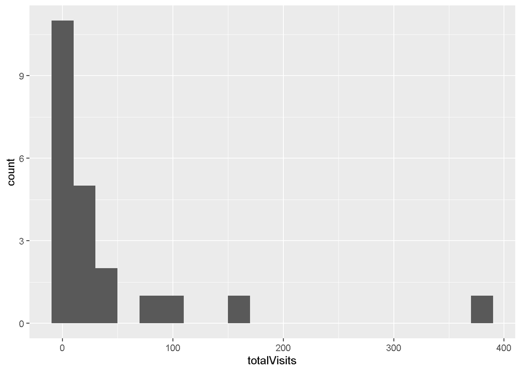

```r
# Create a dataframe of the total visits per individual across the whole of your experiment, irrespective of feeder.
individualvisits<-df%>%
  count(TagID_hex, sort = TRUE)
# Create a new dataframe that excludes individuals that visited less than 5 times
individualvisits2<-individualvisits%>%
  filter(n >5)%>%
  select(TagID_hex,n)

# rename the column of the number of visits to "totalVisits".
names(individualvisits2)[names(individualvisits2) == "n"] <- "totalVisits"

# create a figure of your choice representing the number of visits from your new dataframe.
ggplot(individualvisits2, aes(x=totalVisits)) +geom_histogram(binwidth = 20)
```

```r
# create a dataframe with a list of birds we consider participants and save it as a csv file.
participants <- unique(individualvisits2$TagID_hex)

participants<-as.data.frame(participants)
# write.csv(participants, file="FeederExperimentParticipants.csv"))
```

## 4.7 **EXERCISE** - Time intervals

Previously we created a column that indicated how many seconds had passed since an individual’s previous visit per day. A similar approach can be taken to calculate intervals between visits between individuals (i.e. how long has passed since the previous birds’ visit)

### 4.7.3 change the datetime column to be a POSIXct class

### 4.7.4 create a new column that calculates the time difference from the previous row of a dataframe grouped by date and feeder. Dont forget to use the argument arrange() so the timedate is sequential in your dataframe

### 4.7.5 create a dataframe consisting of individuals that visited a feeder equal or less than 2 second after the previous visitor.

### 4.7.6 create a dataframe of a list of unique individuals that have landed on a feeder within 2 second of the previous visitor

Extra code, not in the exercise, but perhaps useful: how many RFID devices an individual visits

```r
# check how many feeders each individual visited
IDFeeder<-df%>%
  count(feeder, TagID_hex, sort = TRUE)
IDFeeder<-IDFeeder%>%
  count(TagID_hex, sort = TRUE)
summary(IDFeeder$n)
```

```
##    Min. 1st Qu.  Median    Mean 3rd Qu.    Max.
##   1.000   1.000   2.000   2.136   3.000   3.000
```

**Exercise answers**

```r
# clear your global environment
rm(list = ls(all.names = TRUE))


# choose the appropriate working directory

setwd("F:/RWorkspace/GitHub/RFID-workshop/data/outputFiles")

# call your most recent dataset

df<-read.delim("Masterdf_noRepeats.txt", header=TRUE)

# change the datetime column to be a POSIXct class
class(df$dateTime)
```

```
## [1] "character"
```

```r
df$dateTime <- as.POSIXct(df$dateTime)
class(df$dateTime)
```

```
## [1] "POSIXct" "POSIXt"
```

```r
# create a new column that calculates the time difference from the previous row of a dataframe grouped by date and feeder. Dont forget to use the argument arrange() so the timedate is sequential in your dataframe
df1<-df %>%
  arrange(dateTime)%>%
  group_by(date, feeder) %>%
  mutate(timeBetweenID = dateTime - lag(dateTime))%>%
  arrange(dateTime)%>%
  ungroup()

# create a dataframe consisting of individuals that visited a feeder equal or less than 2 second after the previous visitor.
df1$timeBetweenID <- as.numeric(as.character(df1$timeBetweenID))
class(df1$timeBetweenID)
```

```
## [1] "numeric"
```

```r
df2<-df1%>%
  filter(timeBetweenID <=2)

# create a dataframe of a list of unique individuals that have landed on a feeder within 2 second of the previous visitor
twosec<-unique(df2$TagID_hex)
uniqueDisplacers<-as.data.frame(twosec)
```

## 4.8 **EXERCISE** - Correct and incorrect visits

### 4.8.1 Create a column called “correctChoice” where visits to F01 contain the character “Y” and visits to the other incorrect feeders contain the character “N”

(hint: filter, then cbind)

**Exercise answers**

Imagine feeder01 is rewarded and feeder02 and feeder03 are not rewarded. How would you include a column called “correctChoice” where visits to feeder01 contain the character “Y” and visits to the incorrect feeders contain the character “N”

```r
F01Y<-df%>%
  filter(feeder=='F01')
F01Y<-cbind(F01Y, correctChoice='Y')

F02N<-df%>%
  filter(feeder=='F02')
F02N<-cbind(F02N, correctChoice='N')

F03N<-df%>%
  filter(feeder=='F03')
F03N<-cbind(F03N, correctChoice='N')

df3<-bind_rows(F01Y, F02N, F03N)

#Note that there are other methods, but this method uses approaches we learned in today's workshop. As you enhance your R coding skills you'll inevitably refine your code.
```

# 5 Define visit type and learning

## 5.1 Get set up

Open R Studio

### 5.1.1 Check R packages installed

```r
#load the following packages
library(tidyverse) #some of the packages below are included in tidyverse
library(rmarkdown)
library(dplyr)
library(tidyr)
library(lubridate)
library(ggplot2)
library(stringi)
library(magrittr) #may not need this

# These are new and need to be installed
library(writexl)
library(readxl)
library(zoo) #rolling function
```

### 5.1.2 Download resources necessary for the workshop

Download the resources from **[my github repository](https://github.com/DrGLDavidson/RFID-workshop)**

## 5.2 Import your dataset to your environment from your working directory.

```r
#clear the global environment so we don't have any conflicts with the next steps

rm(list = ls(all.names = TRUE))

#choose the appropriate working directory

setwd("F:/RWorkspace/GitHub/RFID-workshop/data/outputFiles")

#call your most recent dataset

df<-read.delim("Masterdf_noRepeats.txt", header=TRUE)
head(df)
```

```
##         date            dateTime Hmsec     ID Event Channel    Dur Clks   Freq
## 1 2022-02-04 2022-02-04 10:01:13   467 c1935    146       0      0   32 126464
## 2 2022-02-04 2022-02-04 11:06:19   516 c1931  15597       0 127943   26      0
## 3 2022-02-04 2022-02-04 11:06:32   770 c1935    147       0      6   39 126208
## 4 2022-02-04 2022-02-04 11:17:36   871 c1935    148       0 105573   51 126464
## 5 2022-02-04 2022-02-04 11:17:40   123 c1935    148       0 121015   27 126208
## 6 2022-02-04 2022-02-04 11:17:48   543 c1931  15598       0      0   39      0
##   Edges Reps Type  TagID_hex feeder dateRinged timeRinged btoRingType   btoID
## 1   264    2    1 01103FC949    F01 09/01/2021      11:03           R AKL0680
## 2   442    1    1 01103F7DB1    F02 03/10/2021      10:30           R AAJ5894
## 3   426    3    1 01103F7DB1    F01 03/10/2021      10:30           R AAJ5894
## 4  1168    5    1 01103F3BED    F01 17/10/2021      10:09           R AAJ5895
## 5   174    1    1 01103F3BED    F01 17/10/2021      10:09           R AAJ5895
## 6   388    3    1 01103FE3B3    F02 07/11/2021      12:15           R AJT8118
##   species pitTYPE age sex wing weight timeSincePreviousVisit
## 1      BT       R   5   M   64   11.7                     NA
## 2      GT       R   3   F   73   16.3                     NA
## 3      GT       R   3   F   73   16.3                     NA
## 4      GT       R   3   M   75   18.5                     NA
## 5      GT       R   3   M   75   18.5                      4
## 6      GT       R   3   F   72   18.1                     NA
```

```r
names(df)
```

```
##  [1] "date"                   "dateTime"               "Hmsec"
##  [4] "ID"                     "Event"                  "Channel"
##  [7] "Dur"                    "Clks"                   "Freq"
## [10] "Edges"                  "Reps"                   "Type"
## [13] "TagID_hex"              "feeder"                 "dateRinged"
## [16] "timeRinged"             "btoRingType"            "btoID"
## [19] "species"                "pitTYPE"                "age"
## [22] "sex"                    "wing"                   "weight"
## [25] "timeSincePreviousVisit"
```

## 5.3 Quantifying correct and incorrect visits (i.e. if a bird landed on its assigned feeder according to ListA logic)

```r
#how many individual tags (birds) in our dataset
length(unique(df$TagID_hex))
```

In practice, you will have (or create) a file for each bird indicating which feeder opens for which bird. This is often referred to as “ListA” because this is what the logic is called in the logger.ini file associated with the computerised feeder.

For the purpose of this tutorial, we create a random vector of data to indicate which feeder opens for a given bird. Draw 44 samples from the integers 1:3 with replacement (i.e. each number can be redrawn), and attach that to unique bird IDs.

```r
assignedFeeder<-sample(x = 1:3, size = 44, replace = TRUE)
#unique birds in df
TagID_hex<-unique(df$TagID_hex)

df2<-cbind(TagID_hex, assignedFeeder)
df2<-as.data.frame(df2)

#change values in assignedFeeder to match feeder values in df.

df3 <- df2 %>%
  mutate(assignedFeeder = recode(assignedFeeder,
                           "1" = "F01",
                           "2" = "F02",
                           "3" = "F03"))

df4 <- merge(df, df3, by = "TagID_hex", all = TRUE)

#create a vector of whether values in df4$feeder are identical to df4$assignedFeeder and return TRUE or FALSE
correctVisit <- c()
for (i in 1:nrow(df4)) {
  correctVisit[i] <- identical(df4$feeder[i], df4$assignedFeeder[i])
}

#add the vector to df4
df4$correctVisit <- correctVisit

#create a binary variable column for downstream statistical analyses and figures

df4$correctVisit<-as.character(df4$correctVisit)

df5 <- df4 %>%
  mutate(correctVisitBinary = recode(correctVisit,
                           "TRUE" = "1",
                           "FALSE" = "0"))


write.table(df5, file = "Masterdf_correctVisits.txt",sep="\t",row.names=FALSE)
```

## 5.4 Quantifying learning (i.e. if a bird visits its assigned feeder at a given criterion).

### 5.4.1 In this example, we will use the criterion of 80% correct visits, across a minimum of 20 visits.

First, define participants as birds that have visited at least 20 times.

```r
#filter out birds that have visited at least 20 times

class(df5$correctVisitBinary)
df5$correctVisitBinary<-as.numeric(df5$correctVisitBinary)


df6 <- df5 %>%
  group_by(TagID_hex) %>%
  mutate(visit_count = n()) %>%  #what variable is visit count
  filter(visit_count >= 20) %>%
  ungroup() %>%
  select(-visit_count)
```

Below you will use a function for quantifying how many visits until a bird has met “criterion”. This function was created by Vildan Acar.

We define criterion as 80% correct over 20 visits.

Note that the code also includes a filtering step of birds having to have had at least 20 visits, making the above code redundant. There is no harm in running both. And the above code may be useful if you’re interested in participation only (rather than learning)

Description of the function **success_chec()** written by Vildan Acar.

“correct” is a vector that contains binary values (1 for correct visits, 0 for false visits). Each element should correspond to a visit. The success_check function determines the first instance when a bird meets a specific learning criterion based on visits. For the function: At least 20 consecutive visits are required. The first visit within these 20 consecutive visits must be a correct visit (indicated by window[1] == 1) and 80% or more of these 20 visits must be correct (sum(window)/ 20 >= 0.8) for the criterion to be met. 19 refers to a count related to 20 consecutive visits.

```r
success_check <- function(correct ){
  n <- length(correct)  #what variable is correct
 if (n < 20){
   return(NA)
 }
  for (i in 1:(n-19)) {
    window <- correct[i: (i+ 19)]
    if(window[1] == 1 && sum(window)/ 20 >= 0.8){
      return(i+19)
    }

  }
  return(NA)
}

#### birds visiting >20 ####

#apply criterion check function
results20 <- df5 %>%
  group_by(TagID_hex) %>%
  summarise(criterion = success_check(correctVisitBinary)) #here "correctVisitBinary" is the column with 0 or 1 values and should be numerical
head(results20)
view(results20)
```

You will see there are many NAs. This is because most birds have yet to learn under our criteria.

To demonstrate, you could alter the values in the function so it is less stringent (and simply because our dataset is small, birds have yet to learn). The participation will be 5 visits, and 80% correct in 5 visits

```r
success_check2 <- function(correct ){
  n <- length(correct)  #what variable is correct
 if (n < 5){
   return(NA)
 }
  for (i in 1:(n-4)) {
    window <- correct[i: (i+ 4)]
    if(window[1] == 1 && sum(window)/ 5 >= 0.8){
      return(i+4)
    }

  }
  return(NA)
}

#apply criterion check function
results5 <- df5 %>%
  group_by(TagID_hex) %>%
  summarise(criterion = success_check2(correctVisitBinary)) #notice the function is changed here to "success_check2"
head(results5)
view(results5)
```

While there are still a lot of NAs, but you can see there are more birds that learned, and the number of visits it took to learn. As your dataset gets larger, so will number of birds meeting criterion.

These file/tally will be useful data to keep track of what is happening with the experiment every time you generate data.

If you wish to save this data, you could do that now.

```r
path_out = 'F:/RWorkspace/GitHub/RFID-workshop/data/outputFiles'
write.csv(results5, file.path(path_out,'birdsReachingCriterion_5visits.csv'))
```

# 6 Correcting for variation in participation at different learning phases

## 6.1 Get set up

Open R Studio

### 6.1.1 Check R packages installed

```r
#load the following packages
library(rmarkdown)
library(tidyverse)
```

### 6.1.2 Download resources necessary for the workshop

In the previous chapters, we worked with a dataset spanning five days of an experiment. However, learning experiments in the field often run for longer, and individuals typically progress through a series of distinct learning phases.

For this chapter, we’ll use a new dataset called *criterion_multiplePhases.txt*, available in the GitHub repository. This dataset includes individuals from multiple learning phases — not just initial learning, but also one or more reversal learning phases.

Download the new dataset from **[here](https://github.com/DrGLDavidson/RFID-workshop)**.

## 6.2 Import your dataset to your environment from your working directory.

```r
#clear the global environment so we don't have any conflicts with the next steps

rm(list = ls(all.names = TRUE))

#choose the appropriate working directory

setwd("F:/RWorkspace/GitHub/RFID-workshop/data/")

#call your most recent dataset

df<-read.delim("criterion_multiplePhases.txt", header=TRUE)
head(df)
```

```
##    TagID_hex learningPhase criterion btoRingType   btoID species age sex wing
## 1 01103F7A57            IL        20           N ABR6163      BT   4   M   67
## 2 01103F7A57           RL1        NA           N ABR6163      BT   4   M   67
## 3 01103F9E19            IL        36           N ABR6082      BT   3   U   61
## 4 01103F9E19           RL1        39           N ABR6082      BT   3   U   61
## 5 01103F9E19           RL2        22           N ABR6082      BT   3   U   61
## 6 01103FA023           RL1        NA           N ABR6443      BT   3   F   62
##   weight
## 1   10.6
## 2   10.6
## 3    9.8
## 4    9.8
## 5    9.8
## 6   10.5
```

```r
names(df)
```

```
##  [1] "TagID_hex"     "learningPhase" "criterion"     "btoRingType"
##  [5] "btoID"         "species"       "age"           "sex"
##  [9] "wing"          "weight"
```

One of the columns in this dataset is learningPhase. This column contains labels for each individual’s phase in the experiment, including one initial learning phase **(IL)**, followed by two reversal learning phases **(RL1 and RL2)**.

During an experiment, as data is collected over time, multiple phases of the experiment may occur. Therefore, when conducting your own experiments, you will need to add a column to your dataset that identifies which learning phase the data corresponds to. This step is important for accurately labeling and interpreting your data (see Tutorial 2 for more details on data upload and organisation).

If you are following this tutorial with your own real data, keep in mind that the *criterion for each learning phase is calculated separately.* Your dataset should look similar to the *df* object after calculating *criterion* as explained in Chapter 5 seperately for each learning phase and merging it with other bird itentifications such as species, sex i.e.

### 6.2.1 Understanding learning phases in cognitive experiments

In associative learning experiments, individuals are often tested across multiple phases, each designed to probe different aspects of cognition.

The first phase is *initial learning (IL)*. Here, individuals are introduced to a stimulus-reward contingency. For example, in an experiment setup with multiple feeders, a single feeder provides a food reward to an individual. Over several days, individuals learn/or fail to learn this association through repeated visits.

Once this association is established, or designated time for that phase passes, the experimental conditions change: the previously rewarded stimulus becomes unrewarded, and vice versa. This is known as *reversal learning (RL)*. Reversal learning assesses the ability to adapt when prior rules no longer apply.

In our RFID-based field experiments, during IL, all birds are assigned randomly to a feeder associated with a reward. After around 5–10 days (depending on the experimental setup), the contingency is reversed, and birds are reassigned to different feeders. This process can be repeated to include multiple reversals (e.g., RL1, RL2), providing insights into how learning patterns change over time and across contexts.

### 6.2.2 Why we need to correct learning phase labels

In typical learning experiments conducted in controlled lab environments, all individuals can be exposed to learning phases simultaneously and under identical conditions. But in field experiments, especially those involving voluntary participation like ours, individuals do not always enter the experiment at the same time.

This introduces a challenge. Our datasets typically label visits based on the planned schedule of the experiment — for example in *df* :

- IL: 13–17 January
- RL1: 17–22 January
- RL2: 22–27 January

However, some birds may not have participated during IL or RL1, and only began interacting with the feeder setup during RL2. If we rely solely on the experiment schedule to assign phase labels, we might wrongly assume that these birds are in their second reversal, when in fact they are just beginning to learn the original task.

This matters because each individual’s learning history influences how we interpret their behaviour. A visit pattern from a bird in its first learning phase means something different than the same pattern from a bird in its third phase.

To make meaningful comparisons, we need to relabel learning phases on a per-bird basis, based on when each individual first began participating. This ensures that we accurately capture the learning trajectory of each bird, rather than imposing a structure based on the experiment timeline alone.

## 6.3 Identifying learning set participation

To begin, let’s visualise the participation to each bird in each phase of the experiment.

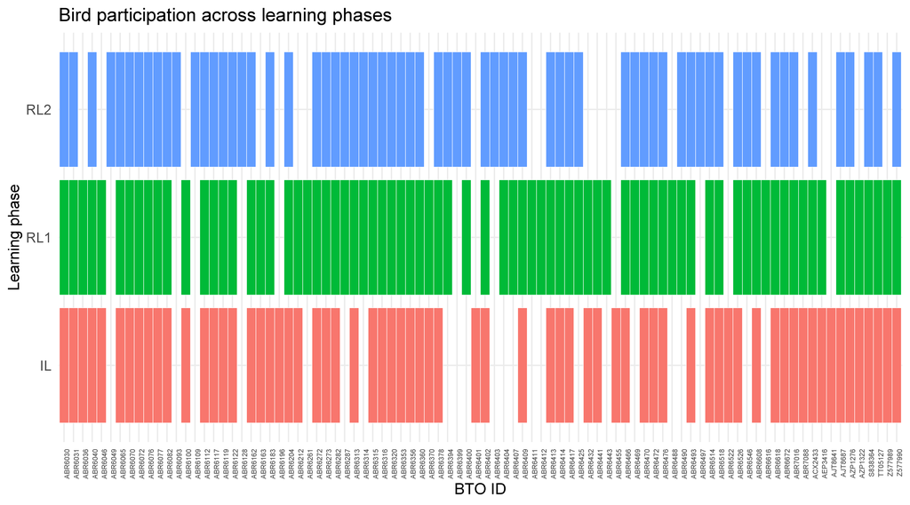

```r
# change the 'learningPhase' and 'btoID' columns to factors for better visualization
df$learningPhase <- factor(df$learningPhase, levels = c("IL", "RL1", "RL2"))
df$btoID <- as.factor(df$btoID)

#plot a geom tile
ggplot(df,
       aes(x = btoID,
           y = learningPhase,
           fill = learningPhase)) +
  geom_tile(color = "white",
            width = 1,
            height = 0.9) +
  labs(title = "Bird participation across learning phases",
    x = "BTO ID",
    y = "Learning phase") +
  theme_minimal() +
  theme(axis.text.x = element_text(angle = 90, hjust = 1, size = 5), #x axis text aesthetics
        axis.text.y = element_text(size = 10), #y axis text aesthetics
        legend.position = "none")
```

As seen in the plot, while most birds participated in all three phases, some individuals missed certain learning phases. For these individuals, we need to correct their actual learning trajectories.

### 6.3.1 EXERCISE

To understand the situation better, create:

#### 6.3.1.1 A bar chart visualising number of birds participated in each learning phase

#### 6.3.1.2 A bar chart visualising number of learning phases earch bird participated

## 6.4 Exercise answers

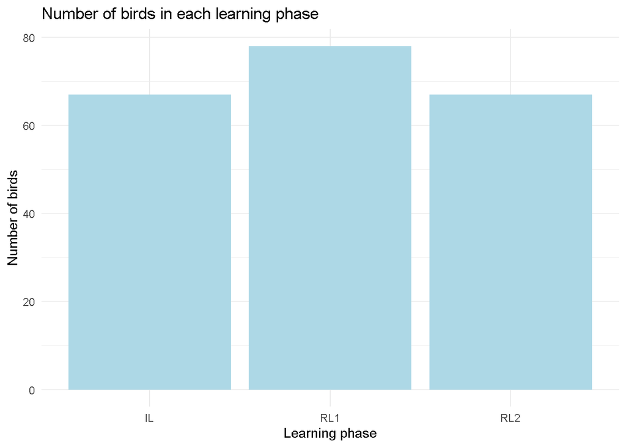

```r
# A bar chart visualising number of birds participated in each learning phase
df %>%
  group_by(learningPhase) %>%
  summarise(n_birds = n_distinct(btoID)) %>%
  ggplot(aes(x = learningPhase,
             y = n_birds)) +
  geom_bar(stat = "identity",
           fill = "lightblue") +
  labs(title = "Number of birds in each learning phase",
    x = "Learning phase",
    y = "Number of birds") +
  theme_minimal()
```

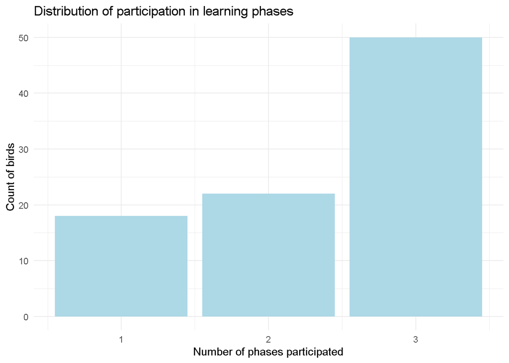

```r
# A bar chart visualising number of learning phases earch bird participated

df %>%
  group_by(btoID, species) %>%
  summarise(phases_participated = n_distinct(learningPhase)) %>%
  ggplot(aes(x = phases_participated)) +
  geom_bar(fill = "lightblue") +
  labs(title = "Distribution of participation in learning phases",
       x = "Number of phases participated",
       y = "Count of birds") +
  theme_minimal()
```

### 6.4.1 Correcting learning phase assignments

To reassign the new phases, we need to make sure the data is ordered by species, learning phase, and bird ID first.

```r
df <- df %>%
  arrange(species, learningPhase, btoID)
head(df)
```

```
##    TagID_hex learningPhase criterion btoRingType   btoID species age sex wing
## 1 3B001856B3            IL        20           N ABR6030      BT   3   U   64
## 2 3B0018947C            IL        54           N ABR6065      BT   3   U   65
## 3 3B0018F7C4            IL        20           N ABR6070      BT   3   U   64
## 4 3B0018D222            IL        20           N ABR6072      BT   3   F   62
## 5 3B001909A5            IL        20           N ABR6076      BT   3   U   NA
## 6 3B00185D64            IL        38           N ABR6077      BT   3   F   60
##   weight
## 1   10.5
## 2   11.0
## 3   10.4
## 4   10.0
## 5     NA
## 6    9.8
```

Then, we assign each bird its corrected learning phase by numbering the sequence of participation and reassigning the appropriate phase:

```r
df2 <- df %>%
  group_by(btoID) %>%
  mutate(totalPhaseCount = row_number()) %>%  #create a new column counting total number of phases participated
  ungroup() %>%
  mutate(correctedPhase = case_when(
    totalPhaseCount == 1 ~ "IL", #if the phase count is 1, this means that phase is IL for that individual (IL only)
    totalPhaseCount == 2 ~ "RL1", # IL+RL1, 2 phases total
    totalPhaseCount == 3 ~ "RL2")) %>% # IL+RL1+RL2, 3 phases total
  select(-totalPhaseCount) #remove phase count column
```

These correction makes sure that birds are classified based on their actual learning experience rather than the experimental phase they happened to start using feeders. This new assignments will allow us to analyse the individual differences in cognitive abilities while accounting for differences in individual learning trajectories.

You can directly compare the learningPhase (before correction) and correctedPhase (after correction) in the existing df:

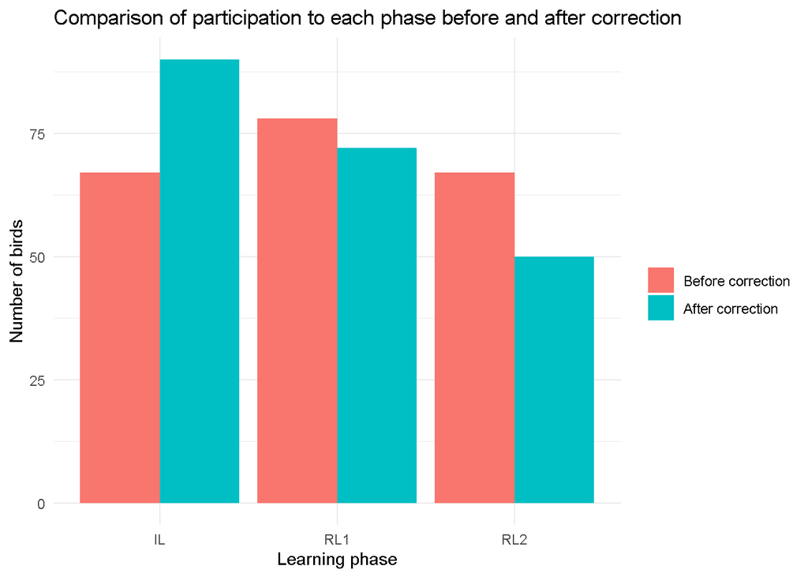

```r
df2 %>%
  gather(key = "phaseType", value = "phase",
         learningPhase, correctedPhase) %>% #create two new columns to get long format from learningpHase and correctedPhase
  mutate(phaseType = recode(phaseType,
                            learningPhase = "Before correction",
                            correctedPhase = "After correction")) %>% #rename
  mutate(phaseType = factor(phaseType,
                            levels = c("Before correction",
                                       "After correction")))  %>% #factor it so bars are ordered as before and after in plot
  ggplot(aes(x = phase, fill = phaseType)) +
  geom_bar(position = "dodge") +
  labs(title = "Comparison of participation to each phase before and after correction",
       x = "Learning phase",
       y = "Number of birds",
       fill = " ") +
  theme_minimal()
```

You can now see now there are a lot of birds started using feeders at different times, resulting with them having participated fewer learning phases.

If you wish to save this data, you could do that now.

```r
path_out = 'F:/RWorkspace/GitHub/RFID-workshop/data/outputFiles'
write.csv(df2, file.path(path_out,'criterion_phasesCorrected.csv'))
```